# R markdown lab

1. Try compiling this document using the “Knit HTML” button. What files are produced?
2. Edit the output to be “word_document” and recompile. What files are produced?
3. Try running the chunk below by pressing the green play button on the far right. What happens?

```r
x = seq(from  = 1, to = 20, by = .5)
x
```

```
##  [1]  1.0  1.5  2.0  2.5  3.0  3.5  4.0  4.5  5.0  5.5  6.0  6.5  7.0  7.5  8.0
## [16]  8.5  9.0  9.5 10.0 10.5 11.0 11.5 12.0 12.5 13.0 13.5 14.0 14.5 15.0 15.5
## [31] 16.0 16.5 17.0 17.5 18.0 18.5 19.0 19.5 20.0
```

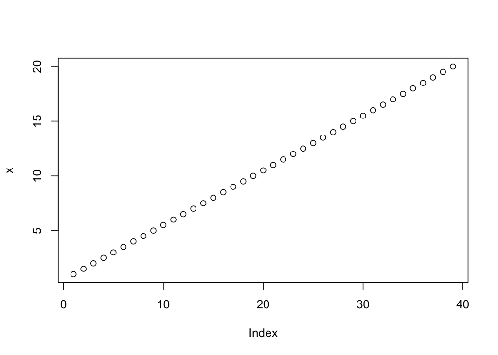

```r
plot(x)
```

### This is a primary header. Add a secondary header with ## on the line below and recompile.

4. Try pressing the run previous chunk button - the button that is to the left of the play button. What happens?

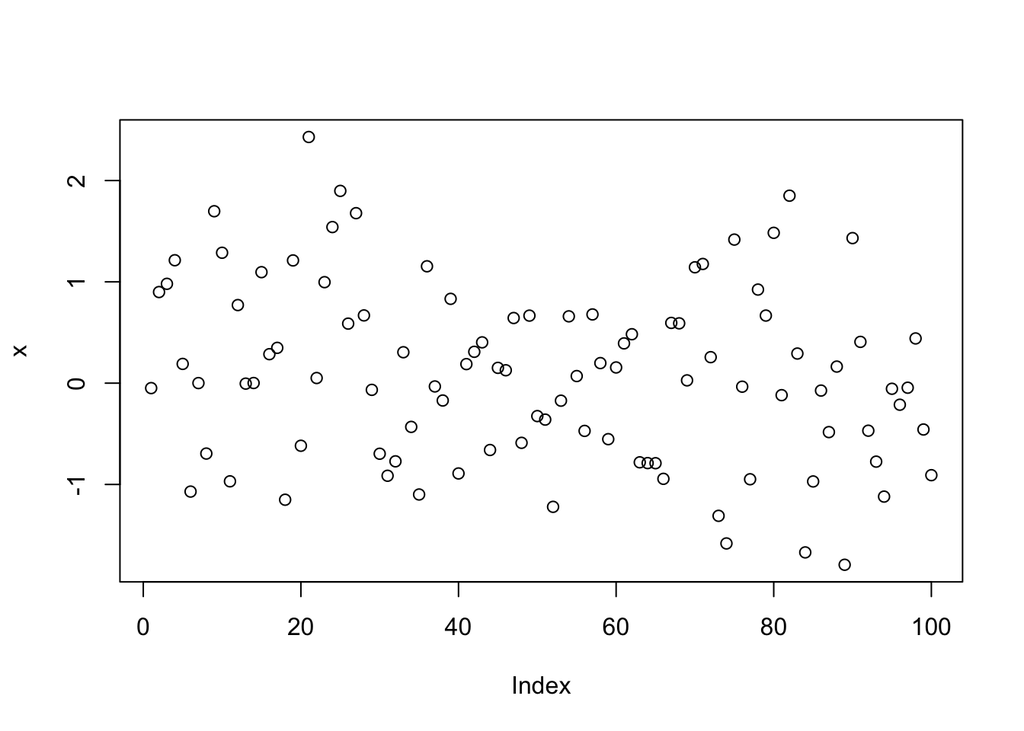

```r
x = rnorm(100)
plot(x)
```

5. Add a chunk option of fig.width = 10 to this plot, see what happens when you knit.

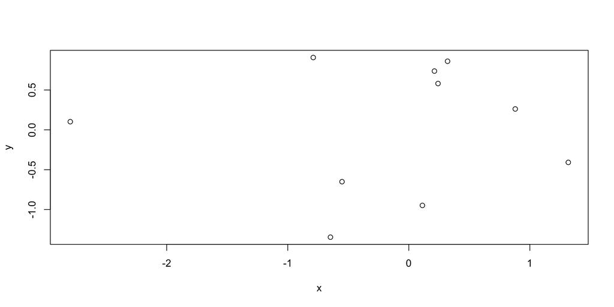

```r
x = rnorm(10)
y = rnorm(10)
plot(x,y)
```

6. Add a chunk option of echo=FALSE and see what happens when you knit.

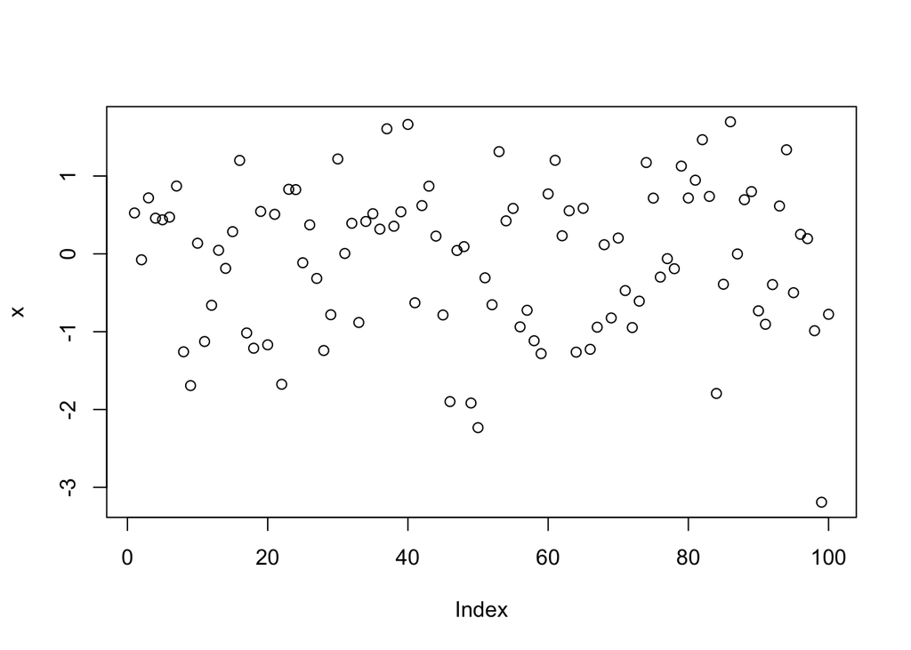

7. Check out the docs at: http://rmarkdown.rstudio.com/ and look under formats.
8. Check out the output of this inline code when you knit the document: 60
9. Install the `devtools package` by copy pasting install.packages(“devtools”) into your console. Then load the package using `libray(devtools)` and the command `session_info()` in this chunk and look at the output.

```r
#install.packages("devtools")
library(devtools)
```

[session information not shown]